# ADA Final Project Analysis

Yosef Chernet

2025-11-26

## INTRODUCTION

The following analysis uses data from the 2021–2022 National Health and  
Nutrition Examination Survey (NHANES) to address the question:

> Among non-institutionalized U.S. adults aged 18–45 years, is serum  
> 25-hydroxyvitamin D level associated with current depressive symptoms  
> measured by the Patient Health Questionnaire-9 (PHQ-9)?

We begin by importing the NHANES data files and preparing an analytic  
dataset for regression modelling and multiple imputation.

## LOAD PACKAGES

```r
library(haven)      # read_xpt for SAS transport files
library(dplyr)      # data manipulation
library(tidyr)      # data tidying
library(naniar)     # missingness summaries
library(mice)       # multiple imputation
library(survey)     # complex survey design + models
library(car)        # VIF (if needed later)
```

```r
library(ggplot2)    # plots
library(table1)     # descriptive Table 1
library(flextable)  # table formatting
```

## IMPORT ALL DATA FILES

```r
cat("Importing NHANES data files...\n")
```

```
## Importing NHANES data files...
```

```r
# Core demographics and survey design
demo <- read_xpt("DEMO_L.xpt")

# Main exposure: Vitamin D
vid <- read_xpt("VID_L.xpt")

# Main outcome: Depression (PHQ-9)
dpq <- read_xpt("DPQ_L.xpt")

# Covariates
bmx <- read_xpt("BMX_L.xpt")         # Body measures (BMI)
paq <- read_xpt("PAQ_L.xpt")         # Physical activity
diq <- read_xpt("DIQ_L.xpt")         # Diabetes
bpq <- read_xpt("BPQ_L.xpt")         # Blood pressure/hypertension
mcq <- read_xpt("MCQ_L.xpt")         # Medical conditions
alq <- read_xpt("ALQ_L.xpt")         # Alcohol use
ucpreg <- read_xpt("UCPREG_L.xpt")   # Pregnancy test (urine)

cat("✓ All files imported successfully\n\n")
```

```
## ✓ All files imported successfully
```

## MERGING DATASETS

Merging Separate datasets.

```r
cat("Merging datasets...\n")
```

```
## Merging datasets...
```

```r
nhanes_merged <- demo %>%
  left_join(vid, by = "SEQN") %>%
  left_join(dpq, by = "SEQN") %>%
  left_join(bmx, by = "SEQN") %>%
  left_join(paq, by = "SEQN") %>%
  left_join(diq, by = "SEQN") %>%
  left_join(bpq, by = "SEQN") %>%
  left_join(mcq, by = "SEQN") %>%
  left_join(alq, by = "SEQN") %>%
  left_join(ucpreg, by = "SEQN")

cat("✓ Datasets merged\n")
```

```
## ✓ Datasets merged
```

```r
cat(sprintf("  Total observations: %d\n\n", nrow(nhanes_merged)))
```

```
##   Total observations: 11933
```

## SELECT VARIABLES OF INTEREST

```r
cat("Selecting analysis variables...\n")
```

```
## Selecting analysis variables...
```

```r
nhanes_analysis <- nhanes_merged %>%
  select(
    # IDs and survey design variables
    SEQN,           # Respondent sequence number
    SDMVSTRA,       # Masked variance pseudo-stratum
    SDMVPSU,        # Masked variance pseudo-PSU
    WTPH2YR,        # Phlebotomy subsample 2-year weight

    # Demographics
    RIDAGEYR,       # Age
    RIAGENDR,       # Sex
    RIDRETH3,       # Race/ethnicity
    DMDEDUC2,       # Education
    INDFMPIR,       # Income-to-poverty ratio
    RIDEXPRG,       # Pregnancy status (20-44y women)
    RIDEXMON,       # 6-month exam period (for seasonality)

    # Main exposure: Vitamin D
    LBXVIDMS,       # 25-hydroxyvitamin D (nmol/L)

    # Main outcome: PHQ-9 items
    DPQ010, DPQ020, DPQ030, DPQ040, DPQ050,
    DPQ060, DPQ070, DPQ080, DPQ090,
    DPQ100,         # Difficulty (not part of score)

    # Body measures
    BMXBMI,         # BMI

    # Physical activity
    PAD800,         # Mins of moderate physical activity

    # Chronic conditions
    DIQ010,         # Diabetes
    BPQ020,         # Hypertension
    BPQ150,         # Taking BP meds (optional)

    # Medical conditions for chronic disease count
    MCQ010,         # Asthma
    MCQ160A,        # Arthritis
    MCQ160B,        # Congestive heart failure
    MCQ160C,        # Coronary heart disease
    MCQ160D,        # Angina
    MCQ160E,        # Heart attack
    MCQ160F,        # Stroke
    MCQ160P,        # COPD/emphysema/chronic bronchitis
    MCQ220,         # Cancer

    # Alcohol
    ALQ142,         # Frequency past 12 months

    # Pregnancy test
    URXPREG         # Urine pregnancy result
  )

cat("✓ Variables selected\n\n")
```

```
## ✓ Variables selected
```

```r
cat("Checking survey weights distribution...\n\n")
```

```
## Checking survey weights distribution...
```

```r
# Summary of phlebotomy weights
cat("WTPH2YR (Phlebotomy 2-year weight) summary:\n")
```

```
## WTPH2YR (Phlebotomy 2-year weight) summary:
```

```r
summary(nhanes_analysis$WTPH2YR)
```

```
##    Min. 1st Qu.  Median    Mean 3rd Qu.    Max.    NA's
##       0   17132   29685   37081   48969  253479    3206
```

```r
cat("\n")
```

```r
# Count participants with positive weights
n_with_weight <- sum(nhanes_analysis$WTPH2YR > 0, na.rm = TRUE)
n_total <- nrow(nhanes_analysis)
cat(sprintf("Participants with positive phlebotomy weight: %d / %d (%.1f%%)\n\n",
            n_with_weight, n_total, 100 * n_with_weight / n_total))
```

```
## Participants with positive phlebotomy weight: 7626 / 11933 (63.9%)
```

```r
# Check for zero or missing weights
n_zero_weight <- sum(nhanes_analysis$WTPH2YR == 0, na.rm = TRUE)
n_missing_weight <- sum(is.na(nhanes_analysis$WTPH2YR))

if (n_zero_weight > 0) {
  cat(sprintf("WARNING: %d participants have zero phlebotomy weight\n", n_zero_weight))
}
```

```
## WARNING: 1101 participants have zero phlebotomy weight
```

```r
if (n_missing_weight > 0) {
  cat(sprintf("WARNING: %d participants have missing phlebotomy weight\n", n_missing_weight))
}
```

```
## WARNING: 3206 participants have missing phlebotomy weight
```

## APPLY INCLUSION/EXCLUSION CRITERIA

```r
n_initial <- nrow(nhanes_analysis)
cat(sprintf("  Starting N: %d\n", n_initial))
```

```
##   Starting N: 11933
```

```r
# Filter: Age 18-45
nhanes_analysis <- nhanes_analysis %>%
  filter(RIDAGEYR >= 18 & RIDAGEYR <= 45)

n_age <- nrow(nhanes_analysis)
cat(sprintf("  After age filter (18-45): %d (excluded: %d)\n",
            n_age, n_initial - n_age))
```

```
##   After age filter (18-45): 3103 (excluded: 8830)
```

```r
# Exclude pregnant participants
nhanes_analysis <- nhanes_analysis %>%
  filter(
    (is.na(RIDEXPRG) | RIDEXPRG != 1) &  # Not pregnant per exam
    (is.na(URXPREG) | URXPREG != 1)      # Not pregnant per urine test
  )

n_preg <- nrow(nhanes_analysis)
cat(sprintf("  After pregnancy exclusion: %d (excluded: %d)\n",
            n_preg, n_age - n_preg))
```

```
##   After pregnancy exclusion: 3062 (excluded: 41)
```

```r
# Ensure positive phlebotomy weight (critical for vitamin D analysis)
nhanes_analysis <- nhanes_analysis %>%
  filter(!is.na(WTPH2YR) & WTPH2YR > 0)

n_weight <- nrow(nhanes_analysis)
cat(sprintf("  After requiring positive WTPH2YR: %d (excluded: %d)\n",
            n_weight, n_preg - n_weight))
```

```
##   After requiring positive WTPH2YR: 2154 (excluded: 908)
```

```r
cat("\n✓ Inclusion/exclusion criteria applied\n\n")
```

```
##
## ✓ Inclusion/exclusion criteria applied
```

## RENAME/RECODE VARIABLES

```r
cat("Renaming and recoding variables...\n")
```

```
## Renaming and recoding variables...
```

```r
nhanes_analysis <- nhanes_analysis %>%
  rename(
    # Demographics
    age                  = RIDAGEYR,
    sex                  = RIAGENDR,
    race_ethnicity       = RIDRETH3,
    education            = DMDEDUC2,
    income_poverty_ratio = INDFMPIR,
    pregnant_exam        = RIDEXPRG,
    exam_period          = RIDEXMON,
    # Vitamin D
    vitamin_d            = LBXVIDMS,
    # PHQ-9 items
    phq9_interest        = DPQ010,
    phq9_depressed       = DPQ020,
    phq9_sleep           = DPQ030,
    phq9_tired           = DPQ040,
    phq9_appetite        = DPQ050,
    phq9_failure         = DPQ060,
    phq9_concentrate     = DPQ070,
    phq9_psychomotor     = DPQ080,
    phq9_suicidal        = DPQ090,
    phq9_difficulty      = DPQ100,
    # Body measures
    bmi                  = BMXBMI,
    # Physical activity
    Phymins              = PAD800,
    # Chronic conditions
    diabetes             = DIQ010,
    hypertension         = BPQ020,
    bp_meds              = BPQ150,
    asthma               = MCQ010,
    arthritis            = MCQ160A,
    chf                  = MCQ160B,
    chd                  = MCQ160C,
    angina               = MCQ160D,
    heart_attack         = MCQ160E,
    stroke               = MCQ160F,
    copd                 = MCQ160P,
    cancer               = MCQ220,
    # Alcohol
    alcohol_freq         = ALQ142,
    # Pregnancy test
    pregnant_urine       = URXPREG
  ) %>%
  mutate(
    # Sex
    sex = factor(sex, levels = 1:2,
                 labels = c("Male", "Female")),
    # Race/ethnicity
    race_ethnicity = factor(
      race_ethnicity,
      levels = 1:7,
      labels = c("Mexican American", "Other Hispanic",
                 "Non-Hispanic White", "Non-Hispanic Black",
                 "Non-Hispanic Asian", "Other Race", "Multiracial")
    ),
    # Education
    education = factor(
      education,
      levels = 1:5,
      labels = c("Less than 9th grade", "9–11th grade",
                 "High school grad/GED", "Some college/AA",
                 "College graduate or above")
    ),

    # Physical activity
    phymins_cat = case_when(
      Phymins == 0   & Phymins < 30    ~ "<30 minutes",
      Phymins >= 30 & Phymins < 60    ~ "30–59 minutes",
      Phymins >= 60 & Phymins <= 720  ~ "≥60 minutes",
      Phymins %in% c(7777, 9999) |
        is.na(Phymins)                ~ NA_character_
    ),
    phymins_cat = factor(
      phymins_cat,
      levels  = c("<30 minutes", "30–59 minutes", "≥60 minutes"),
      ordered = TRUE
    ),

    # Recode binary yes/no variables: 1 = Yes, 2 = No
    across(
      any_of(c("diabetes","hypertension","bp_meds","asthma","arthritis","chf","chd",
               "angina","heart_attack","stroke","copd","cancer")),
      ~ case_when(. == 1 ~ TRUE,
                  . == 2 ~ FALSE,
                  TRUE   ~ NA)
    ),

    # Alcohol frequency categories
    alcohol_cat = case_when(
      alcohol_freq %in% 1:4              ~ "High alcohol use",
      alcohol_freq %in% 5:7              ~ "Moderate alcohol use",
      alcohol_freq %in% c(0, 8, 9, 10)   ~ "Low alcohol use",
      alcohol_freq %in% c(77, 99) |
        is.na(alcohol_freq)              ~ NA_character_
    ),
    alcohol_cat = factor(
      alcohol_cat,
      levels  = c("Low alcohol use",
                  "Moderate alcohol use",
                  "High alcohol use"),
      ordered = TRUE
    )
  )

cat("✓ Variables renamed and recoded\n\n")
```

```
## ✓ Variables renamed and recoded
```

## DERIVED VARIABLES

```r
cat("Creating derived variables...\n")
```

```
## Creating derived variables...
```

```r
nhanes_analysis <- nhanes_analysis %>%
  mutate(
    # PHQ-9 total score and binary outcome
    phq9_total = rowSums(dplyr::select(., phq9_interest:phq9_suicidal),
                         na.rm = FALSE),
    depressive_symptoms = case_when(
      phq9_total >= 10 ~ TRUE,
      phq9_total < 10  ~ FALSE,
      TRUE             ~ NA
    ),

    # Vitamin D in ng/mL and categories
    vitamin_d_ngml = vitamin_d / 2.496,
    vitamin_d_cat = factor(
      case_when(
        vitamin_d_ngml < 20                        ~ "Deficient",
        vitamin_d_ngml >= 20 & vitamin_d_ngml < 30 ~ "Insufficient",
        vitamin_d_ngml >= 30                       ~ "Sufficient",
        TRUE                                       ~ NA_character_
      ),
      levels = c("Sufficient", "Insufficient", "Deficient")
    ),

    # BMI categories
    bmi_cat = factor(
      case_when(
        bmi < 18.5             ~ "Underweight",
        bmi >= 18.5 & bmi < 25 ~ "Normal",
        bmi >= 25   & bmi < 30 ~ "Overweight",
        bmi >= 30              ~ "Obese",
        TRUE                   ~ NA_character_
      ),
      levels = c("Normal", "Overweight", "Obese", "Underweight")
    ),

    # BMI collapsed categories
    bmi_cat3 = factor(
      case_when(
        bmi < 25             ~ "Normal/Underweight",
        bmi >= 25 & bmi < 30 ~ "Overweight",
        bmi >= 30            ~ "Obese",
        TRUE                 ~ NA_character_
      ),
      levels = c("Normal/Underweight", "Overweight", "Obese")
    ),

    # Chronic disease count (from logicals)
    chronic_disease_count = rowSums(
      dplyr::select(., diabetes, hypertension, asthma, arthritis, chf, chd,
                    angina, heart_attack, stroke, copd, cancer),
      na.rm = TRUE
    ),
    any_chronic_disease = case_when(
      if_all(c(diabetes, hypertension, asthma, arthritis, chf, chd,
               angina, heart_attack, stroke, copd, cancer), is.na) ~ NA,
      chronic_disease_count > 0  ~ TRUE,
      chronic_disease_count == 0 ~ FALSE
    ),

    # Age categories
    age_cat = factor(
      case_when(
        age >= 18 & age < 25 ~ "18–24",
        age >= 25 & age < 35 ~ "25–34",
        age >= 35 & age <=45 ~ "35–45",
        TRUE                 ~ NA_character_
      ),
      levels = c("18–24", "25–34", "35–45")
    )
  )

cat("✓ Derived variables created\n\n")
```

```
## ✓ Derived variables created
```

## CREATE ANALYTIC SAMPLE

We restrict to participants with complete data on the exposure, outcome,  
and survey design variables.

```r
cat("Creating analytic sample...\n")
```

```
## Creating analytic sample...
```

```r
nhanes_analytic <- nhanes_analysis %>%
  filter(
    !is.na(vitamin_d),
    !is.na(phq9_total),
    !is.na(SDMVSTRA),
    !is.na(SDMVPSU),
    !is.na(WTPH2YR) & WTPH2YR > 0  # Ensure complete survey design info
  )

cat(sprintf("Analytic sample size: %d\n\n", nrow(nhanes_analytic)))
```

```
## Analytic sample size: 1802
```

## MISSINGNESS IN ANALYTIC SAMPLE

```r
# Variables of interest for missingness summary

# Variables of interest for missingness summary
vars_of_interest <- c(
  # IDs / survey design
  "SEQN", "SDMVSTRA", "SDMVPSU", "WTPH2YR",

  # Demographics
  "age", "sex", "race_ethnicity", "education", "income_poverty_ratio",

  # Exposure & outcome
  "vitamin_d", "vitamin_d_ngml", "vitamin_d_cat",
  "phq9_total", "depressive_symptoms",

  # Other covariates
  "bmi", "bmi_cat3",
  "diabetes", "hypertension",
  "alcohol_cat",
  "Phymins", "phymins_cat",
  "chronic_disease_count", "any_chronic_disease",
  "age_cat"
)

missing_summary <- nhanes_analytic %>%
  dplyr::select(dplyr::all_of(vars_of_interest)) %>%
  naniar::miss_var_summary() %>%
  arrange(desc(pct_miss))

missing_summary
```

```
## # A tibble: 24 × 3
##    variable             n_miss pct_miss
##    <chr>                 <int>    <num>
##  1 phymins_cat             392   21.8
##  2 alcohol_cat             337   18.7
##  3 Phymins                 243   13.5
##  4 income_poverty_ratio    219   12.2
##  5 education               207   11.5
##  6 diabetes                 26    1.44
##  7 bmi                       9    0.499
##  8 bmi_cat3                  9    0.499
##  9 SEQN                      0    0
## 10 SDMVSTRA                  0    0
## # ℹ 14 more rows
```

```r
vars_no_impute <- c(
  # Survey design (CRITICAL - must be complete)
  "SDMVSTRA", "SDMVPSU", "WTPH2YR",
  # Core variables
  "depressive_symptoms", "phq9_total",
  "vitamin_d",
  "age", "sex", "race_ethnicity",
  "bmi",
  "diabetes", "hypertension",
  "chronic_disease_count"
)

nhanes_cc_base <- nhanes_analytic %>%
  filter(complete.cases(dplyr::select(., dplyr::all_of(vars_no_impute))))

cat(sprintf(
  "Base complete-case N (before imputing education, income_poverty_ratio, Phymins, alcohol_freq): %d\n\n",
  nrow(nhanes_cc_base)
))
```

```
## Base complete-case N (before imputing education, income_poverty_ratio, Phymins, alcohol_freq): 1767
```

```r
# Verify survey design completeness
cat("Survey design variables in base dataset:\n")
```

```
## Survey design variables in base dataset:
```

```r
cat(sprintf("  All SDMVSTRA complete: %s\n", all(!is.na(nhanes_cc_base$SDMVSTRA))))
```

```
##   All SDMVSTRA complete: TRUE
```

```r
cat(sprintf("  All SDMVPSU complete: %s\n", all(!is.na(nhanes_cc_base$SDMVPSU))))
```

```
##   All SDMVPSU complete: TRUE
```

```r
cat(sprintf("  All WTPH2YR positive: %s\n\n", all(nhanes_cc_base$WTPH2YR > 0)))
```

```
##   All WTPH2YR positive: TRUE
```

```r
# Check remaining missingness in the variables that will be imputed
nhanes_cc_base %>%
  dplyr::select(education, income_poverty_ratio, Phymins, alcohol_freq) %>%
  naniar::miss_var_summary()
```

```
## # A tibble: 4 × 3
##   variable             n_miss pct_miss
##   <chr>                 <int>    <num>
## 1 alcohol_freq            327     18.5
## 2 Phymins                 235     13.3
## 3 income_poverty_ratio    218     12.3
## 4 education               202     11.4
```

## MISSING DATA PATTERN FOR IMPUTATION

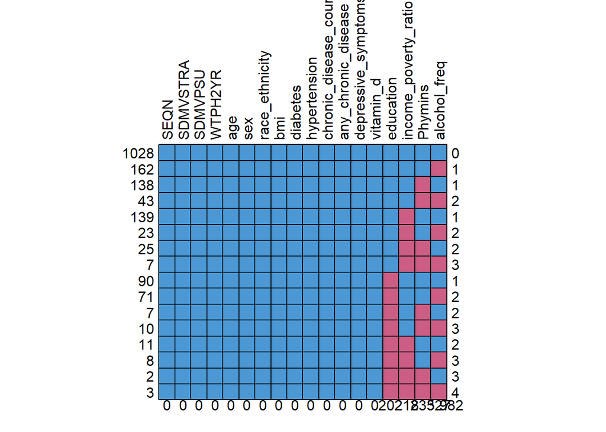

```
##      SEQN SDMVSTRA SDMVPSU WTPH2YR age sex race_ethnicity bmi diabetes
## 1028    1        1       1       1   1   1              1   1        1
## 162     1        1       1       1   1   1              1   1        1
## 138     1        1       1       1   1   1              1   1        1
## 43      1        1       1       1   1   1              1   1        1
## 139     1        1       1       1   1   1              1   1        1
## 23      1        1       1       1   1   1              1   1        1
## 25      1        1       1       1   1   1              1   1        1
## 7       1        1       1       1   1   1              1   1        1
## 90      1        1       1       1   1   1              1   1        1
## 71      1        1       1       1   1   1              1   1        1
## 7       1        1       1       1   1   1              1   1        1
## 10      1        1       1       1   1   1              1   1        1
## 11      1        1       1       1   1   1              1   1        1
## 8       1        1       1       1   1   1              1   1        1
```

[output cut: 39 more lines]

```r
impute_df <- nhanes_cc_base %>%
  dplyr::select(
    # IDs / design & weights (keep but won't impute)
    SEQN, SDMVSTRA, SDMVPSU, WTPH2YR,

    # Variables to be imputed
    education,
    income_poverty_ratio,
    Phymins,
    alcohol_freq,

    # Predictors for imputation
    age, sex, race_ethnicity,
    bmi,
    diabetes, hypertension,
    chronic_disease_count, any_chronic_disease,
    depressive_symptoms,
    vitamin_d
  )

md.pattern(impute_df, rotate.names = TRUE)
```

```r
# Initial run to obtain default methods and predictor matrix
init <- mice(impute_df, maxit = 0)
meth <- init$method
pred <- init$predictorMatrix

# Turn off imputation for all variables
meth[] <- ""

# Turn on imputation only for education (factor) and income_poverty_ratio (numeric)
meth["education"]            <- "polyreg"  # multinomial logistic
meth["income_poverty_ratio"] <- "pmm"      # predictive mean matching
meth["Phymins"]              <- "pmm"      # predictive mean matching
meth["alcohol_freq"]         <- "pmm"      # predictive mean matching

# Do not use design variables as predictors
pred[, c("SEQN", "SDMVSTRA", "SDMVPSU", "WTPH2YR")] <- 0

# Run imputation
set.seed(600)
imp <- mice(
  impute_df,
  m               = 10,
  maxit           = 20,
  method          = meth,
  predictorMatrix = pred,
  printFlag       = FALSE
)
cat("✓ Multiple imputation completed\n")
```

```
## ✓ Multiple imputation completed
```

```r
print(imp)
```

```
## Class: mids
## Number of multiple imputations:  10
## Imputation methods:
##                  SEQN              SDMVSTRA               SDMVPSU
##                    ""                    ""                    ""
##               WTPH2YR             education  income_poverty_ratio
##                    ""             "polyreg"                 "pmm"
##               Phymins          alcohol_freq                   age
##                 "pmm"                 "pmm"                    ""
##                   sex        race_ethnicity                   bmi
##                    ""                    ""                    ""
##              diabetes          hypertension chronic_disease_count
##                    ""                    ""                    ""
##   any_chronic_disease   depressive_symptoms             vitamin_d
##                    ""                    ""                    ""
## PredictorMatrix:
##                      SEQN SDMVSTRA SDMVPSU WTPH2YR education
## SEQN                    0        0       0       0         1
## SDMVSTRA                0        0       0       0         1
## SDMVPSU                 0        0       0       0         1
## WTPH2YR                 0        0       0       0         1
## education               0        0       0       0         0
## income_poverty_ratio    0        0       0       0         1
##                      income_poverty_ratio Phymins alcohol_freq age sex
## SEQN                                    1       1            1   1   1
## SDMVSTRA                                1       1            1   1   1
## SDMVPSU                                 1       1            1   1   1
## WTPH2YR                                 1       1            1   1   1
## education                               1       1            1   1   1
## income_poverty_ratio                    0       1            1   1   1
##                      race_ethnicity bmi diabetes hypertension
## SEQN                              1   1        1            1
## SDMVSTRA                          1   1        1            1
## SDMVPSU                           1   1        1            1
## WTPH2YR                           1   1        1            1
## education                         1   1        1            1
## income_poverty_ratio              1   1        1            1
##                      chronic_disease_count any_chronic_disease
## SEQN                                     1                   1
## SDMVSTRA                                 1                   1
## SDMVPSU                                  1                   1
## WTPH2YR                                  1                   1
## education                                1                   1
## income_poverty_ratio                     1                   1
##                      depressive_symptoms vitamin_d
## SEQN                                   1         1
## SDMVSTRA                               1         1
## SDMVPSU                                1         1
## WTPH2YR                                1         1
## education                              1         1
## income_poverty_ratio                   1         1
## Number of logged events:  800
##   it im                  dep    meth                              out
## 1  1  1            education polyreg race_ethnicityNon-Hispanic Asian
## 2  1  1 income_poverty_ratio     pmm race_ethnicityNon-Hispanic Asian
## 3  1  1              Phymins     pmm race_ethnicityNon-Hispanic Asian
## 4  1  1         alcohol_freq     pmm race_ethnicityNon-Hispanic Asian
## 5  1  2            education polyreg race_ethnicityNon-Hispanic Asian
## 6  1  2 income_poverty_ratio     pmm race_ethnicityNon-Hispanic Asian
```

## INSPECT IMPUTED VALUES

```r
# Check which variables were actually imputed
cat("Variables that were imputed:\n")
```

```
## Variables that were imputed:
```

```r
print(names(imp$imp))
```

```
##  [1] "SEQN"                  "SDMVSTRA"              "SDMVPSU"
##  [4] "WTPH2YR"               "education"             "income_poverty_ratio"
##  [7] "Phymins"               "alcohol_freq"          "age"
## [10] "sex"                   "race_ethnicity"        "bmi"
## [13] "diabetes"              "hypertension"          "chronic_disease_count"
## [16] "any_chronic_disease"   "depressive_symptoms"   "vitamin_d"
```

```r
cat("\n")
```

```r
# Imputed values for income_poverty_ratio (if it exists)
if ("income_poverty_ratio" %in% names(imp$imp)) {
  cat("First 10 imputed values for income_poverty_ratio:\n")
  print(head(imp$imp$income_poverty_ratio, 10))
  cat("\n")
}
```

```
## First 10 imputed values for income_poverty_ratio:
##       1    2    3    4    5    6    7    8    9   10
## 21 1.05 3.70 2.82 5.00 5.00 5.00 4.21 1.95 5.00 5.00
## 22 1.74 0.58 0.52 1.57 0.19 0.70 1.12 1.84 0.37 0.24
## 23 1.08 1.35 0.05 1.30 2.29 0.03 1.22 0.48 1.18 3.22
## 29 2.61 3.69 5.00 5.00 3.40 5.00 4.12 3.43 5.00 3.69
## 52 4.22 1.67 0.74 1.85 2.33 0.11 2.31 0.28 0.65 5.00
## 60 1.74 3.62 1.51 5.00 2.82 1.74 0.70 3.56 1.67 5.00
## 64 0.70 2.73 3.31 5.00 4.90 1.06 2.83 1.30 2.50 3.31
## 66 3.13 3.30 4.46 3.60 2.16 5.00 3.62 4.78 4.12 5.00
## 70 1.37 2.92 2.20 0.02 0.87 5.00 2.09 1.77 5.00 0.71
## 81 1.17 3.69 0.66 2.87 2.31 0.96 3.28 3.02 1.74 0.63
```

```r
# Imputed values for education (if it exists)
if ("education" %in% names(imp$imp)) {
  cat("First 10 imputed values for education:\n")
  print(head(imp$imp$education, 10))
  cat("\n")
}
```

```
## First 10 imputed values for education:
##                             1                         2
## 8   College graduate or above           Some college/AA
## 9        High school grad/GED              9–11th grade
## 26               9–11th grade      High school grad/GED
## 45               9–11th grade              9–11th grade
## 56  College graduate or above College graduate or above
## 86               9–11th grade College graduate or above
## 97  College graduate or above           Some college/AA
## 98  College graduate or above College graduate or above
## 100 College graduate or above College graduate or above
## 146           Some college/AA           Some college/AA
##                             3                         4
## 8   College graduate or above           Some college/AA
## 9             Some college/AA College graduate or above
```

[output cut: 41 more lines]

```r
# Imputed values for Phymins (if it exists)
if ("Phymins" %in% names(imp$imp)) {
  cat("First 10 imputed values for Phymins:\n")
  print(head(imp$imp$Phymins, 10))
  cat("\n")
}
```

```
## First 10 imputed values for Phymins:
##      1  2   3  4  5   6   7  8   9  10
## 6   30 60  60 60 60  90 720 15 120  60
## 24  40 30 180 45 30  30  30 30  30  45
## 33  30 90  45 45 60  60 120 90  30  30
## 34  60 60  30 30 30 120 120 20  30  60
## 36 120 90  30 60 60  45  60 30  30 600
## 41 180 30  30 45 30   1 120 60  90  60
## 42 120 30 120 60 30  45  60 35  30  30
## 45 240 45  30 60 60  30  30 30 180  60
## 51 120 60   1 90 60  60  30 60  60  30
## 64  30 60  90 15 10  30  60 60 120  60
```

```r
# Imputed values for alcohol_freq (if it exists)
if ("alcohol_freq" %in% names(imp$imp)) {
  cat("First 10 imputed values for alcohol_freq:\n")
  print(head(imp$imp$alcohol_freq, 10))
  cat("\n")
}
```

```
## First 10 imputed values for alcohol_freq:
##     1 2  3  4  5  6  7 8  9 10
## 3   0 6  0 10  6 10  3 0  0  9
## 6   7 9  7  0  4  9 10 8  8  6
## 9  10 7  7 10  4 10  9 0  6 10
## 14  6 0 10  5  7 10  0 7  7  4
## 26  4 0  0  9  3  9  6 9  9  6
## 27  7 7  4  6  0 10 10 5  9  0
## 29  7 7  9  5  0  2  9 5  0  6
## 32 10 0  8  8  0  0  0 4 10 10
## 34  6 0 10  7 10  0  2 3  9  0
## 36  9 9 10  7  6  9 10 0  0 10
```

```r
# Basic imputation summary
cat("\n=== IMPUTATION SUMMARY ===\n")
```

```
##
## === IMPUTATION SUMMARY ===
```

```r
print(imp)
```

```
## Class: mids
## Number of multiple imputations:  10
## Imputation methods:
##                  SEQN              SDMVSTRA               SDMVPSU
##                    ""                    ""                    ""
##               WTPH2YR             education  income_poverty_ratio
##                    ""             "polyreg"                 "pmm"
##               Phymins          alcohol_freq                   age
##                 "pmm"                 "pmm"                    ""
##                   sex        race_ethnicity                   bmi
##                    ""                    ""                    ""
##              diabetes          hypertension chronic_disease_count
##                    ""                    ""                    ""
##   any_chronic_disease   depressive_symptoms             vitamin_d
##                    ""                    ""                    ""
## PredictorMatrix:
##                      SEQN SDMVSTRA SDMVPSU WTPH2YR education
## SEQN                    0        0       0       0         1
## SDMVSTRA                0        0       0       0         1
## SDMVPSU                 0        0       0       0         1
## WTPH2YR                 0        0       0       0         1
## education               0        0       0       0         0
## income_poverty_ratio    0        0       0       0         1
##                      income_poverty_ratio Phymins alcohol_freq age sex
## SEQN                                    1       1            1   1   1
## SDMVSTRA                                1       1            1   1   1
## SDMVPSU                                 1       1            1   1   1
## WTPH2YR                                 1       1            1   1   1
## education                               1       1            1   1   1
## income_poverty_ratio                    0       1            1   1   1
##                      race_ethnicity bmi diabetes hypertension
## SEQN                              1   1        1            1
## SDMVSTRA                          1   1        1            1
## SDMVPSU                           1   1        1            1
## WTPH2YR                           1   1        1            1
## education                         1   1        1            1
## income_poverty_ratio              1   1        1            1
##                      chronic_disease_count any_chronic_disease
## SEQN                                     1                   1
## SDMVSTRA                                 1                   1
## SDMVPSU                                  1                   1
## WTPH2YR                                  1                   1
## education                                1                   1
## income_poverty_ratio                     1                   1
##                      depressive_symptoms vitamin_d
## SEQN                                   1         1
## SDMVSTRA                               1         1
## SDMVPSU                                1         1
## WTPH2YR                                1         1
## education                              1         1
## income_poverty_ratio                   1         1
## Number of logged events:  800
##   it im                  dep    meth                              out
## 1  1  1            education polyreg race_ethnicityNon-Hispanic Asian
## 2  1  1 income_poverty_ratio     pmm race_ethnicityNon-Hispanic Asian
## 3  1  1              Phymins     pmm race_ethnicityNon-Hispanic Asian
## 4  1  1         alcohol_freq     pmm race_ethnicityNon-Hispanic Asian
## 5  1  2            education polyreg race_ethnicityNon-Hispanic Asian
## 6  1  2 income_poverty_ratio     pmm race_ethnicityNon-Hispanic Asian
```

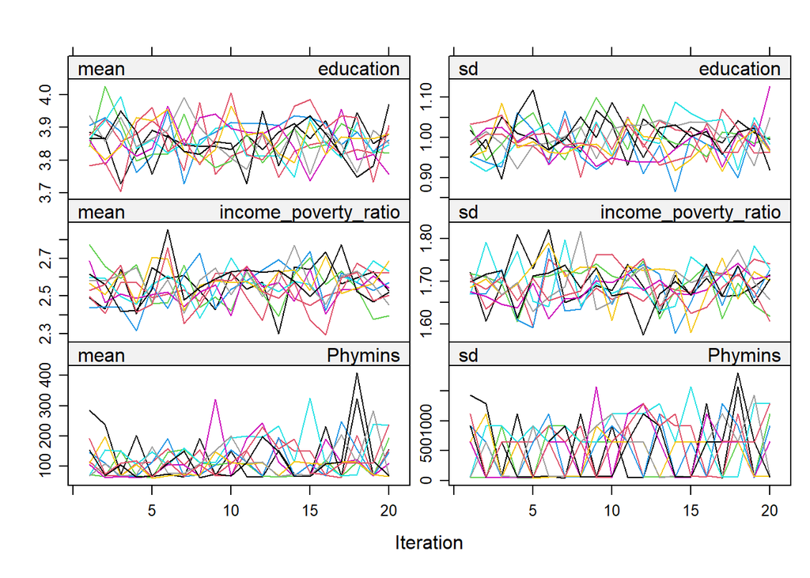

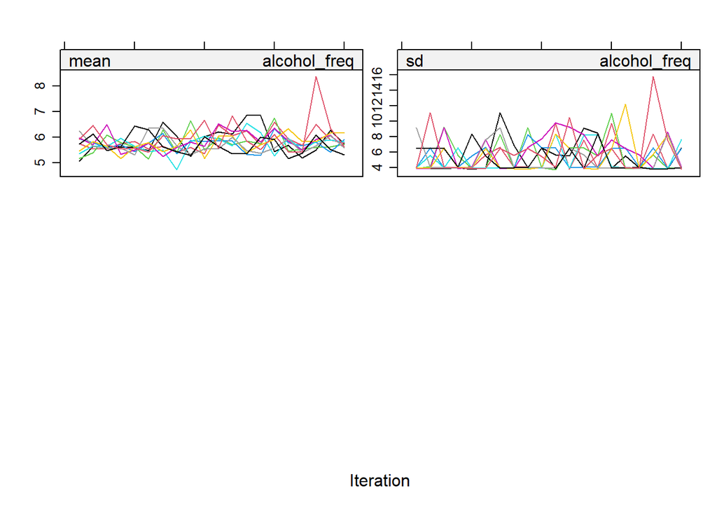

```r
# Convergence plot (optional - shows if imputation converged)
plot(imp)
```

## DERIVED VARIABLES AFTER IMPUTATION

```r
# Get all imputations in long format (including original as .imp = 0 if you want)
completed_long <- complete(imp, action = "long", include = TRUE)

# Recreate derived variables that depend on imputed fields
completed_long <- completed_long %>%
  mutate(
    # Income-to-poverty ratio categories (now using imputed income_poverty_ratio)
    poverty_cat = factor(
      case_when(
        income_poverty_ratio < 1.3                             ~ "<1.3 (Low)",
        income_poverty_ratio >= 1.3 & income_poverty_ratio < 3 ~ "1.3–<3.0 (Middle)",
        income_poverty_ratio >= 3.0                            ~ "≥3.0 (High)",
        TRUE                                                    ~ NA_character_
      ),
      levels = c("≥3.0 (High)", "1.3–<3.0 (Middle)", "<1.3 (Low)")
    ),

    # Physical activity categories from imputed Phymins
    phymins_cat = case_when(
      Phymins > 0   & Phymins < 30    ~ "<30 minutes",
      Phymins >= 30 & Phymins < 60    ~ "30–59 minutes",
      Phymins >= 60 & Phymins <= 720  ~ "≥60 minutes",
      Phymins %in% c(7777, 9999) |
        is.na(Phymins)                ~ NA_character_
    ),
    phymins_cat = factor(
      phymins_cat,
      levels  = c("<30 minutes", "30–59 minutes", "≥60 minutes"),
      ordered = TRUE
    ),

    # Alcohol categories from imputed alcohol_freq
    alcohol_cat = case_when(
      alcohol_freq %in% 1:4            ~ "High alcohol use",
      alcohol_freq %in% 5:7            ~ "Moderate alcohol use",
      alcohol_freq %in% c(0, 8, 9, 10) ~ "Low alcohol use",
      alcohol_freq %in% c(77, 99) |
        is.na(alcohol_freq)            ~ NA_character_
    ),
    alcohol_cat = factor(
      alcohol_cat,
      levels  = c("Low alcohol use",
                  "Moderate alcohol use",
                  "High alcohol use"),
      ordered = TRUE
    )
  )

# Quick check
completed_long %>%
  group_by(.imp) %>%
  summarise(
    n = n(),
    miss_poverty   = sum(is.na(poverty_cat)),
    miss_phymins   = sum(is.na(phymins_cat)),
    miss_alcohol   = sum(is.na(alcohol_cat))
  )
```

```
## # A tibble: 11 × 5
##     .imp     n miss_poverty miss_phymins miss_alcohol
##    <int> <int>        <int>        <int>        <int>
##  1     0  1767          218          237          329
##  2     1  1767            0            4            3
##  3     2  1767            0            4            3
##  4     3  1767            0            5            2
##  5     4  1767            0            4            3
##  6     5  1767            0            6            4
##  7     6  1767            0            3            2
##  8     7  1767            0            2            2
##  9     8  1767            0            2            2
## 10     9  1767            0            2            2
## 11    10  1767            0            6            2
```

## TABLE 1: DESCRIPTIVE CHARACTERISTICS

```r
# Use first completed dataset from the imputation and (re)create derived vars
imp1 <- complete(imp, action = 1) %>%
  mutate(
    # Vitamin D in ng/mL and categories
    vitamin_d_ngml = vitamin_d / 2.496,
    vitamin_d_cat = factor(
      case_when(
        vitamin_d_ngml < 20                        ~ "Deficient",
        vitamin_d_ngml >= 20 & vitamin_d_ngml < 30 ~ "Insufficient",
        vitamin_d_ngml >= 30                       ~ "Sufficient",
        TRUE                                       ~ NA_character_
      ),
      levels = c("Sufficient", "Insufficient", "Deficient")
    ),

    # Physical activity categories from imputed Phymins
    phymins_cat = case_when(
      Phymins > 0   & Phymins < 30    ~ "<30 minutes",
      Phymins >= 30 & Phymins < 60    ~ "30–59 minutes",
      Phymins >= 60 & Phymins <= 720  ~ "≥60 minutes",
      Phymins %in% c(7777, 9999) |
        is.na(Phymins)                ~ NA_character_
    ),
    phymins_cat = factor(
      phymins_cat,
      levels  = c("<30 minutes", "30–59 minutes", "≥60 minutes"),
      ordered = TRUE
    ),

    # Alcohol categories from imputed alcohol_freq
    alcohol_cat = case_when(
      alcohol_freq %in% 1:4            ~ "High alcohol use",
      alcohol_freq %in% 5:7            ~ "Moderate alcohol use",
      alcohol_freq %in% c(0, 8, 9, 10) ~ "Low alcohol use",
      alcohol_freq %in% c(77, 99) |
        is.na(alcohol_freq)            ~ NA_character_
    ),
    alcohol_cat = factor(
      alcohol_cat,
      levels  = c("Low alcohol use",
                  "Moderate alcohol use",
                  "High alcohol use"),
      ordered = TRUE
    )
  )

# Add labels for nicer Table 1 output
label(imp1$vitamin_d_cat)        <- "Vitamin D category"
label(imp1$age)                  <- "Age (years)"
label(imp1$sex)                  <- "Sex"
label(imp1$race_ethnicity)       <- "Race/ethnicity"
label(imp1$education)            <- "Education"
label(imp1$income_poverty_ratio) <- "Income-to-poverty ratio"
label(imp1$bmi)                  <- "Body mass index (kg/m²)"
label(imp1$phymins_cat)          <- "Leisure-time PA (minutes/bout)"
label(imp1$alcohol_cat)          <- "Alcohol use (past year)"
label(imp1$any_chronic_disease)  <- "Any chronic disease"
label(imp1$depressive_symptoms)  <- "Depressive symptoms (PHQ-9 ≥10)"

# ---- Table 1 stratified BY vitamin D category ----
tab1 <- table1(
  ~ sex +
    age +
    race_ethnicity +
    education +
    income_poverty_ratio +
    bmi +
    phymins_cat +
    alcohol_cat +
    any_chronic_disease +
    depressive_symptoms
  | vitamin_d_cat,
  data = imp1
)

tab1  # prints nicely in HTML
```

|  | Sufficient (N=563) | Insufficient (N=648) | Deficient (N=556) | Overall (N=1767) |
| --- | --- | --- | --- | --- |
| Sex |  |  |  |  |
| Male | 231 (41.0%) | 322 (49.7%) | 287 (51.6%) | 840 (47.5%) |
| Female | 332 (59.0%) | 326 (50.3%) | 269 (48.4%) | 927 (52.5%) |
| Age (years) |  |  |  |  |
| Mean (SD) | 33.3 (8.02) | 31.4 (8.14) | 30.5 (8.37) | 31.7 (8.25) |
| Median [Min, Max] | 34.0 [18.0, 45.0] | 32.0 [18.0, 45.0] | 31.0 [18.0, 45.0] | 32.0 [18.0, 45.0] |
| Race/ethnicity |  |  |  |  |
| Mexican American | 40 (7.1%) | 72 (11.1%) | 86 (15.5%) | 198 (11.2%) |
| Other Hispanic | 48 (8.5%) | 86 (13.3%) | 80 (14.4%) | 214 (12.1%) |
| Non-Hispanic White | 378 (67.1%) | 357 (55.1%) | 164 (29.5%) | 899 (50.9%) |
| Non-Hispanic Black | 29 (5.2%) | 56 (8.6%) | 133 (23.9%) | 218 (12.3%) |
| Non-Hispanic Asian | 0 (0%) | 0 (0%) | 0 (0%) | 0 (0%) |
| Other Race | 27 (4.8%) | 40 (6.2%) | 44 (7.9%) | 111 (6.3%) |
| Multiracial | 41 (7.3%) | 37 (5.7%) | 49 (8.8%) | 127 (7.2%) |
| Education |  |  |  |  |
| Less than 9th grade | 13 (2.3%) | 9 (1.4%) | 19 (3.4%) | 41 (2.3%) |
| 9–11th grade | 19 (3.4%) | 43 (6.6%) | 54 (9.7%) | 116 (6.6%) |
| High school grad/GED | 78 (13.9%) | 117 (18.1%) | 135 (24.3%) | 330 (18.7%) |
| Some college/AA | 144 (25.6%) | 211 (32.6%) | 189 (34.0%) | 544 (30.8%) |
| College graduate or above | 309 (54.9%) | 268 (41.4%) | 159 (28.6%) | 736 (41.7%) |
| Income-to-poverty ratio |  |  |  |  |
| Mean (SD) | 3.22 (1.62) | 2.80 (1.70) | 2.41 (1.65) | 2.81 (1.69) |
| Median [Min, Max] | 3.34 [0, 5.00] | 2.73 [0, 5.00] | 2.06 [0, 5.00] | 2.72 [0, 5.00] |
| Body mass index (kg/m²) |  |  |  |  |
| Mean (SD) | 27.5 (6.63) | 29.0 (7.20) | 30.8 (8.91) | 29.1 (7.73) |
| Median [Min, Max] | 26.2 [16.4, 61.5] | 27.6 [15.0, 69.1] | 29.0 [16.1, 68.9] | 27.3 [15.0, 69.1] |
| Leisure-time PA (minutes/bout) |  |  |  |  |
| <30 minutes | 49 (8.7%) | 55 (8.5%) | 51 (9.2%) | 155 (8.8%) |
| 30–59 minutes | 211 (37.5%) | 227 (35.0%) | 172 (30.9%) | 610 (34.5%) |
| ≥60 minutes | 302 (53.6%) | 365 (56.3%) | 331 (59.5%) | 998 (56.5%) |
| Missing | 1 (0.2%) | 1 (0.2%) | 2 (0.4%) | 4 (0.2%) |
| Alcohol use (past year) |  |  |  |  |
| Low alcohol use | 397 (70.5%) | 460 (71.0%) | 357 (64.2%) | 1214 (68.7%) |
| Moderate alcohol use | 122 (21.7%) | 140 (21.6%) | 147 (26.4%) | 409 (23.1%) |
| High alcohol use | 44 (7.8%) | 45 (6.9%) | 52 (9.4%) | 141 (8.0%) |
| Missing | 0 (0%) | 3 (0.5%) | 0 (0%) | 3 (0.2%) |
| Any chronic disease |  |  |  |  |
| Yes | 197 (35.0%) | 231 (35.6%) | 207 (37.2%) | 635 (35.9%) |
| No | 366 (65.0%) | 417 (64.4%) | 349 (62.8%) | 1132 (64.1%) |
| Depressive symptoms (PHQ-9 ≥10) |  |  |  |  |
| Yes | 78 (13.9%) | 103 (15.9%) | 112 (20.1%) | 293 (16.6%) |
| No | 485 (86.1%) | 545 (84.1%) | 444 (79.9%) | 1474 (83.4%) |

## UNWEIGHTED LOGISTIC REGRESSION WITH IMPUTATION

## ============================

## PRIMARY OBJECTIVE LOGISTIC REGRESSION

## ============================

```r
# 1) Take first completed dataset from the imputation
imp1 <- complete(imp, action = 1) %>%
  mutate(
    # Binary outcome
    dep_bin = if_else(depressive_symptoms, 1L, 0L),

    # Vitamin D in ng/mL and categories
    vitamin_d_ngml = vitamin_d / 2.496,
    vitamin_d_cat = factor(
      case_when(
        vitamin_d_ngml < 20                        ~ "Deficient",
        vitamin_d_ngml >= 20 & vitamin_d_ngml < 30 ~ "Insufficient",
        vitamin_d_ngml >= 30                       ~ "Sufficient",
        TRUE                                       ~ NA_character_
      ),
      levels = c("Sufficient", "Insufficient", "Deficient")
    ),

    # Poverty categories from imputed income_poverty_ratio
    poverty_cat = factor(
      case_when(
        income_poverty_ratio < 1.3                             ~ "<1.3 (Low)",
        income_poverty_ratio >= 1.3 & income_poverty_ratio < 3 ~ "1.3–<3.0 (Middle)",
        income_poverty_ratio >= 3.0                            ~ "≥3.0 (High)",
        TRUE                                                    ~ NA_character_
      ),
      levels = c("≥3.0 (High)", "1.3–<3.0 (Middle)", "<1.3 (Low)")
    ),

    # Physical activity categories from imputed Phymins
    phymins_cat = case_when(
      Phymins > 0   & Phymins < 30    ~ "<30 minutes",
      Phymins >= 30 & Phymins < 60    ~ "30–59 minutes",
      Phymins >= 60 & Phymins <= 720  ~ "≥60 minutes",
      Phymins %in% c(7777, 9999) |
        is.na(Phymins)                ~ NA_character_
    ),
    phymins_cat = factor(
      phymins_cat,
      levels  = c("<30 minutes", "30–59 minutes", "≥60 minutes"),
      ordered = TRUE
    ),

    # Alcohol categories from imputed alcohol_freq
    alcohol_cat = case_when(
      alcohol_freq %in% 1:4            ~ "High alcohol use",
      alcohol_freq %in% 5:7            ~ "Moderate alcohol use",
      alcohol_freq %in% c(0, 8, 9, 10) ~ "Low alcohol use",
      alcohol_freq %in% c(77, 99) |
        is.na(alcohol_freq)            ~ NA_character_
    ),
    alcohol_cat = factor(
      alcohol_cat,
      levels  = c("Low alcohol use",
                  "Moderate alcohol use",
                  "High alcohol use"),
      ordered = TRUE
    )
  )
```

## 2. Primary model: vitamin D and depressive symptoms

Adjusted to:

- Use **imputed** data (`imp1`) instead of pre-imputation `nhanes_analysis`.
- Drop `smoking_status` (no longer in your data).
- Add physical activity (`phymins_cat`) as a lifestyle covariate.
- Keep `chronic_disease_count` as a marker of comorbidity.

```r
## ============================
## PRIMARY OBJECTIVE LOGISTIC REGRESSION
## ============================

# 1. Build analysis dataset from imputed data
nhanes_simple <- imp1 %>%
  mutate(
    vitamin_d_cat = relevel(vitamin_d_cat, ref = "Sufficient")
  ) %>%
  select(
    dep_bin,
    vitamin_d_cat,
    age,
    sex,
    race_ethnicity,
    education,
    income_poverty_ratio,
    bmi,
    phymins_cat,
    alcohol_cat,
    chronic_disease_count
  ) %>%
  drop_na()   # remove any residual NAs (e.g. rare missing categories)

nrow(nhanes_simple)  # sample size used in model
```

```
## [1] 1760
```

```r
# 2. Fit logistic regression (still unweighted, for simplicity)
fit_logit <- glm(
  dep_bin ~ vitamin_d_cat +
    age + sex + race_ethnicity +
    education + income_poverty_ratio +
    bmi +
    phymins_cat + alcohol_cat +
    chronic_disease_count,
  data   = nhanes_simple,
  family = binomial()
)

summary(fit_logit)
```

```
##
## Call:
## glm(formula = dep_bin ~ vitamin_d_cat + age + sex + race_ethnicity +
##     education + income_poverty_ratio + bmi + phymins_cat + alcohol_cat +
##     chronic_disease_count, family = binomial(), data = nhanes_simple)
##
## Coefficients:
##                                     Estimate Std. Error z value Pr(>|z|)
## (Intercept)                        -0.886597   0.648480  -1.367 0.171565
## vitamin_d_catInsufficient           0.064625   0.174682   0.370 0.711412
## vitamin_d_catDeficient              0.311757   0.186932   1.668 0.095365 .
## age                                -0.051710   0.008900  -5.810 6.24e-09 ***
## sexFemale                           0.494513   0.144336   3.426 0.000612 ***
## race_ethnicityOther Hispanic       -0.399941   0.281121  -1.423 0.154834
## race_ethnicityNon-Hispanic White    0.021052   0.223393   0.094 0.924920
## race_ethnicityNon-Hispanic Black   -0.463127   0.276297  -1.676 0.093700 .
## race_ethnicityOther Race           -0.740527   0.427812  -1.731 0.083458 .
## race_ethnicityMultiracial           0.276789   0.289164   0.957 0.338464
## education9–11th grade               0.069751   0.565724   0.123 0.901874
## educationHigh school grad/GED       0.445258   0.528206   0.843 0.399249
## educationSome college/AA            0.551192   0.524667   1.051 0.293463
## educationCollege graduate or above  0.106297   0.543231   0.196 0.844864
## income_poverty_ratio               -0.092562   0.050357  -1.838 0.066044 .
## bmi                                 0.018550   0.008689   2.135 0.032778 *
## phymins_cat.L                       0.027968   0.171219   0.163 0.870246
## phymins_cat.Q                       0.036881   0.138596   0.266 0.790161
## alcohol_cat.L                       0.765373   0.152406   5.022 5.12e-07 ***
## alcohol_cat.Q                       0.360698   0.144200   2.501 0.012371 *
## chronic_disease_count               0.300162   0.082879   3.622 0.000293 ***
## ---
## Signif. codes:  0 '***' 0.001 '**' 0.01 '*' 0.05 '.' 0.1 ' ' 1
##
## (Dispersion parameter for binomial family taken to be 1)
##
##     Null deviance: 1578.4  on 1759  degrees of freedom
## Residual deviance: 1440.2  on 1739  degrees of freedom
## AIC: 1482.2
##
## Number of Fisher Scoring iterations: 5
```

```r
# 3. Odds ratios and 95% CIs
or_table <- cbind(
  OR  = exp(coef(fit_logit)),
  exp(confint.default(fit_logit))
)

colnames(or_table) <- c("OR", "LCL", "UCL")
or_table
```

```
##                                           OR       LCL       UCL
## (Intercept)                        0.4120557 0.1156029 1.4687334
## vitamin_d_catInsufficient          1.0667593 0.7574903 1.5022971
## vitamin_d_catDeficient             1.3658225 0.9468411 1.9702051
## age                                0.9496040 0.9331834 0.9663134
## sexFemale                          1.6396987 1.2356762 2.1758224
## race_ethnicityOther Hispanic       0.6703595 0.3863819 1.1630509
## race_ethnicityNon-Hispanic White   1.0212752 0.6591592 1.5823232
## race_ethnicityNon-Hispanic Black   0.6293130 0.3661697 1.0815607
## race_ethnicityOther Race           0.4768623 0.2061764 1.1029277
## race_ethnicityMultiracial          1.3188886 0.7482922 2.3245826
## education9–11th grade              1.0722410 0.3537912 3.2496591
## educationHigh school grad/GED      1.5608932 0.5543241 4.3952400
## educationSome college/AA           1.7353199 0.6205572 4.8526311
## educationCollege graduate or above 1.1121519 0.3835000 3.2252460
## income_poverty_ratio               0.9115925 0.8259181 1.0061541
## bmi                                1.0187230 1.0015203 1.0362212
## phymins_cat.L                      1.0283627 0.7351988 1.4384270
## phymins_cat.Q                      1.0375692 0.7907584 1.3614144
## alcohol_cat.L                      2.1497959 1.5946629 2.8981815
## alcohol_cat.Q                      1.4343296 1.0812000 1.9027945
## chronic_disease_count              1.3500776 1.1476573 1.5882001
```

## 3. Secondary model: poverty and depressive symptoms

Adjusted to:

- Use **imputed poverty_cat** created above.
- Use `imp1` (imputed data).
- Drop `smoking_status`.
- Include `phymins_cat` and `alcohol_cat` as lifestyle covariates.
- Do not include `income_poverty_ratio` in the poverty model (would be collinear with `poverty_cat`).

```r
## ============================
## SECONDARY MODEL: POVERTY
## ============================

# 1. Build analysis dataset
nhanes_pov <- imp1 %>%
  mutate(
    dep_bin = if_else(depressive_symptoms, 1L, 0L),
    poverty_cat = relevel(poverty_cat, ref = "≥3.0 (High)")
  ) %>%
  select(
    dep_bin,
    poverty_cat,
    age,
    sex,
    race_ethnicity,
    education,
    bmi,
    phymins_cat,
    alcohol_cat,
    chronic_disease_count
  ) %>%
  drop_na()

nrow(nhanes_pov)  # sample size for poverty model
```

```
## [1] 1760
```

```r
# 2. Fit logistic regression with poverty category
fit_pov <- glm(
  dep_bin ~ poverty_cat +
    age + sex + race_ethnicity +
    education +
    bmi +
    phymins_cat + alcohol_cat +
    chronic_disease_count,
  data   = nhanes_pov,
  family = binomial()
)

summary(fit_pov)
```

```
##
## Call:
## glm(formula = dep_bin ~ poverty_cat + age + sex + race_ethnicity +
##     education + bmi + phymins_cat + alcohol_cat + chronic_disease_count,
##     family = binomial(), data = nhanes_pov)
##
## Coefficients:
##                                     Estimate Std. Error z value Pr(>|z|)
## (Intercept)                        -1.251069   0.669806  -1.868 0.061789 .
## poverty_cat1.3–<3.0 (Middle)        0.597474   0.174043   3.433 0.000597 ***
## poverty_cat<1.3 (Low)               0.434412   0.198882   2.184 0.028943 *
## age                                -0.052626   0.008864  -5.937 2.91e-09 ***
## sexFemale                           0.469567   0.143167   3.280 0.001039 **
## race_ethnicityOther Hispanic       -0.384187   0.280957  -1.367 0.171493
## race_ethnicityNon-Hispanic White   -0.021583   0.220180  -0.098 0.921914
## race_ethnicityNon-Hispanic Black   -0.394177   0.274825  -1.434 0.151492
## race_ethnicityOther Race           -0.699331   0.427764  -1.635 0.102080
## race_ethnicityMultiracial           0.289923   0.289150   1.003 0.316019
## education9–11th grade               0.051250   0.563484   0.091 0.927531
## educationHigh school grad/GED       0.379174   0.527148   0.719 0.471960
## educationSome college/AA            0.484487   0.523548   0.925 0.354762
## educationCollege graduate or above  0.056808   0.538096   0.106 0.915922
## bmi                                 0.020279   0.008555   2.370 0.017769 *
## phymins_cat.L                       0.012276   0.171857   0.071 0.943055
## phymins_cat.Q                       0.033329   0.138928   0.240 0.810409
## alcohol_cat.L                       0.789908   0.152861   5.168 2.37e-07 ***
## alcohol_cat.Q                       0.374193   0.144732   2.585 0.009726 **
## chronic_disease_count               0.292330   0.082677   3.536 0.000407 ***
## ---
## Signif. codes:  0 '***' 0.001 '**' 0.01 '*' 0.05 '.' 0.1 ' ' 1
##
## (Dispersion parameter for binomial family taken to be 1)
##
##     Null deviance: 1578.4  on 1759  degrees of freedom
## Residual deviance: 1435.2  on 1740  degrees of freedom
## AIC: 1475.2
##
## Number of Fisher Scoring iterations: 5
```

```r
# 3. Odds ratios and 95% CIs
or_pov <- cbind(
  OR  = exp(coef(fit_pov)),
  exp(confint.default(fit_pov))
)

colnames(or_pov) <- c("OR", "LCL", "UCL")
or_pov
```

```
##                                           OR        LCL       UCL
## (Intercept)                        0.2861987 0.07700653 1.0636719
## poverty_cat1.3–<3.0 (Middle)       1.8175221 1.29221299 2.5563793
## poverty_cat<1.3 (Low)              1.5440545 1.04561983 2.2800871
## age                                0.9487352 0.93239430 0.9653625
## sexFemale                          1.5993010 1.20799781 2.1173579
## race_ethnicityOther Hispanic       0.6810041 0.39264358 1.1811390
## race_ethnicityNon-Hispanic White   0.9786484 0.63563676 1.5067611
## race_ethnicityNon-Hispanic Black   0.6742348 0.39344105 1.1554275
## race_ethnicityOther Race           0.4969178 0.21486782 1.1492054
## race_ethnicityMultiracial          1.3363244 0.75820506 2.3552507
## education9–11th grade              1.0525858 0.34883398 3.1761148
## educationHigh school grad/GED      1.4610778 0.51995274 4.1056582
## educationSome college/AA           1.6233427 0.58178910 4.5295475
## educationCollege graduate or above 1.0584527 0.36867461 3.0387831
## bmi                                1.0204858 1.00351747 1.0377410
## phymins_cat.L                      1.0123515 0.72284762 1.4178031
## phymins_cat.Q                      1.0338903 0.78744217 1.3574701
## alcohol_cat.L                      2.2031939 1.63281724 2.9728148
## alcohol_cat.Q                      1.4538181 1.09474826 1.9306605
## chronic_disease_count              1.3395456 1.13915494 1.5751873
```